# session_3

#### 7. Just explore SB County eco-regions (clipping)

Can plot just pieces using st_intersection (for example, if we only want to plot eco-regions in Santa Barbara County), and crop graphing space with coord_sf() limits.

```r
# Get just SB county
sb <- ca_counties %>%
  filter(NAME == "Santa Barbara")

# Clip eco-region spatial data to intersection with SB county:
eco_clip <- st_intersection(ca_eco, sb)
```

```
## although coordinates are longitude/latitude, st_intersection assumes that they are planar
```

Plot it!

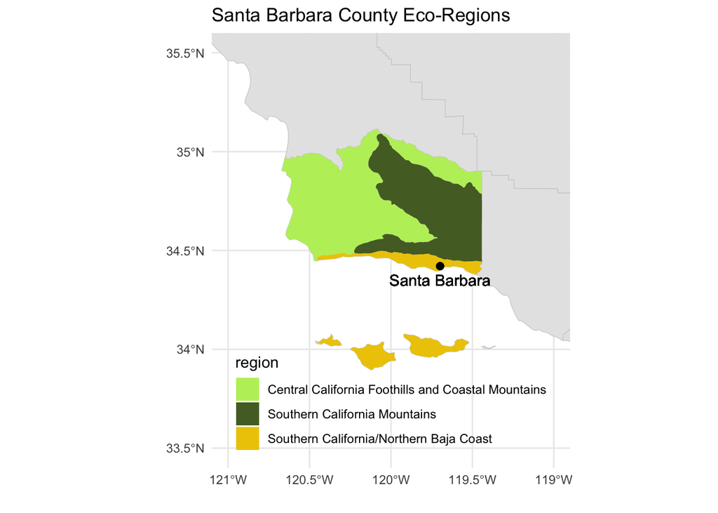

```r
ggplot(eco_clip) +
  geom_sf(data = ca_counties, fill = "gray90", color = "gray80", size = 0.2) + # First add gray California
  geom_sf(aes(fill = region), color = "NA") + # ...then add eco-regions (clipped)
  scale_fill_manual(values = c("darkolivegreen2","darkolivegreen","gold2")) + # Change color scheme
  coord_sf(xlim = c(-121,-119), ylim = c(33.5,35.5)) + # Crop plotting area
  geom_point(aes(x = -119.6982, y = 34.4208), size = 2) + # Add a point for SB City
  geom_text(x = -119.6982, y = 34.35, label = "Santa Barbara") + # Then add a label for it
  theme_minimal() + # Update theme
  theme(legend.position = c(0.5,0.15)) +# Move the legend
  labs(x = "", y = "", title = "Santa Barbara County Eco-Regions")
```

Hooray! Clipped polygons.

Want to see that in tmap? See alternative basemaps at: http://leaflet-extras.github.io/leaflet-providers/preview/ (or use ?leaflet in Console, and click on the link in ‘server’ to leaflet extras)

```r
sb_clip_tmap <- tm_basemap("Esri.WorldImagery") +
  tm_shape(eco_clip) +
  tm_fill("region", palette = c("orange","purple","yellow"), alpha = 0.5)

tmap_mode("view")
```

```
## tmap mode set to interactive viewing
```

```r
sb_clip_tmap
```

[interactive chart not shown]

Super coool.

#### 8. Creating ‘sf’ data from lat/lon recordings

Let’s make a mock dataset tibble (like a df):

```r
my_example <- tribble(
  ~id, ~lon, ~lat,
  "tiger", -119.4, 34.35,
  "lion", -119.41, 34.39,
  "bear", -119.43, 34.38
)
```

Check it out with View(), names, etc.

Now, we want this to be understood as spatial data by R:

```r
animals_sf <- st_as_sf(my_example, coords = c("lon","lat"), crs = 4326)
```

And now R understands it as spatial information (check class(animals_sf)), and we can plot (e.g. using tmap):

```r
animal_map <- tm_shape(animals_sf) +
  tm_dots(labels = "id", col = "purple", size = 0.5)

tmap_mode("view")
```

```
## tmap mode set to interactive viewing
```

```r
animal_map
```

[interactive chart not shown]

#### 9. Chloropleth of dam counts (if time)

Find counts of dams per county:

```r
intersection <- st_intersection(x = ca_dams, y = ca_counties)
```

```
## although coordinates are longitude/latitude, st_intersection assumes that they are planar
```

```r
dams_per_county <- intersection %>%
  group_by(NAME) %>%
  tally()

# Check it out:
# View(dams_per_county)

# Then merge to the ca_counties data:

ca_tot <- ca_counties %>%
  st_join(dams_per_county) %>%
  dplyr::select(NAME.x, n) %>%
  rename(name = NAME.x)
```

```
## although coordinates are longitude/latitude, st_intersects assumes that they are planar
```

```r
# Replace 'NA' counts with value '0' using tidyr::replace_na()
ca_tot <- ca_tot %>%
  tidyr::replace_na(list(n = 0))
```

Make a map with color indicating number of dams:

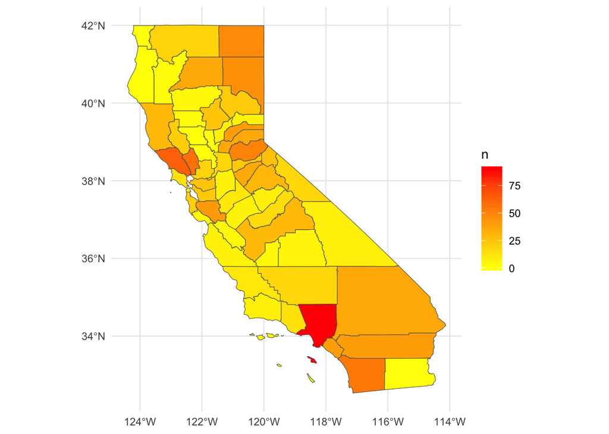

```r
ggplot() +
  geom_sf(data = ca_tot, aes(fill = n), size = 0.2) +
  theme_minimal() +
  scale_fill_continuous(low = "yellow", high = "red")
```

#### Additional resources on spatial data analysis & viz

##### General resources for spatial analysis in R:

- “Geocomputation with R” by Robin Lovelace: https://geocompr.robinlovelace.net/
- sf: https://r-spatial.github.io/sf/articles/sf1.html
- sf & ggplot: https://www.r-spatial.org/r/2018/10/25/ggplot2-sf.html

tmap:

- run ‘vignette(“tmap-getstarted”)’ in Console to see examples
- https://cran.r-project.org/web/packages/tmap/vignettes/tmap-getstarted.html